# **Automatic Airline Feedback Analysis through X (Twitter) using Big Data and NLP.**

- **Name:** Luis Esteban Torres Perdomo

# 1.Introduction

Where social networks have become mainstream channels of interaction between consumers and brands, public opinion regarding airlines services becomes essential for any strategic decision. The project addresses this issue through deep NLP and machine learning for the analysis of tweets airline-related in USA and providing insights into public opinion.

The pipeline includes from exploratory data analysis to semantic topic extraction from leveraging pre-trained language models and LDA modeling. It also encompasses functional features like new tweets sentiment prediction and automatic summarization.

# 2.Objetive

Develop a sentiment analysis pipeline on airline tweets using natural language processing (NLP) and machine learning techniques to discover positive or negative sentiments as well as relevant topics in user Tweets for airlines in the USA.

### 2.1 Specific objectives:

- Clean and transform the data for analysis.
- Automatically classify tweets into positive or negative by supervised learning models, using NLP and machine learning techniques.
- Discover top topics with each sentiment through topic modeling (LDA).
- Create new text prediction and summarization capabilities on new tweets to enable their analysis by airlines.

# 3. Data Source

The datas set is the public sources of Kaggle.com and the link of datasource is :https://www.kaggle.com/datasets/crowdflower/twitter-airline-sentiment [Crowdflower , 2016]

# 4. Data Exploration

First, the libraries needed for the project were imported, and we proceeded to load the dataset and explore its contents.

```python
!pip install gensim
```

```python
import pandas as pd
import numpy as np
import re
import seaborn as sns
import matplotlib.pyplot as plt
from sklearn.model_selection import train_test_split
from sklearn.linear_model import LogisticRegression
from sklearn.metrics import classification_report, confusion_matrix
from sentence_transformers import SentenceTransformer
from sklearn.feature_extraction.text import TfidfVectorizer
from sklearn.metrics.pairwise import cosine_similarity
import networkx as nx
from sklearn.feature_extraction.text import CountVectorizer
from wordcloud import WordCloud
import gensim
import gensim.corpora as corpora
import nltk
from nltk.corpus import stopwords
from nltk.stem import SnowballStemmer
nltk.download('stopwords')
```

```python
df = pd.read_csv("/content/Tweets-airlines.csv")
df= df.copy()
df_random = df.sample(5)
df_random
```

|  | tweet_id | airline_sentiment | airline_sentiment_confidence | airline | name | negativereason_gold | retweet_count | text | tweet_coord | tweet_created | tweet_location | user_timezone |
| --- | --- | --- | --- | --- | --- | --- | --- | --- | --- | --- | --- | --- |
| 3307 | 568536972072865792 | negative | 0.6983 | United | khigdon1 | NaN | 0 | @united why do you bother surveying me! | NaN | 2015-02-19 14:25:51 -0800 | NaN | NaN |
| 13878 | 569697188508348416 | neutral | 0.6784 | American | JonKohler | NaN | 0 | @AmericanAir yea no worries. I'm just going ho... | NaN | 2015-02-22 19:16:08 -0800 | Denver, CO | Eastern Time (US & Canada) |
| 14588 | 569595309279440896 | neutral | 0.6767 | American | RafaANieves | NaN | 0 | @AmericanAir if business class if full but 1st... | NaN | 2015-02-22 12:31:18 -0800 | NaN | Quito |
| 9707 | 569704066760232960 | negative | 1.0000 | US Airways | biscuittmfs | NaN | 0 | @USAirways @AmericanAir you should partner w/ ... | NaN | 2015-02-22 19:43:28 -0800 | NY - SoFlo - The Tardis | Eastern Time (US & Canada) |
| 12822 | 570007852724699136 | negative | 1.0000 | American | vickyyp__ | NaN | 0 | @AmericanAir you're airline is ridiculous | [41.97367122, -87.89700781] | 2015-02-23 15:50:36 -0800 | NaN | Alaska |

Selection of required columns :

```python
df = df[["text", "airline_sentiment"]]
```

```python
sentiments = ["positive", "negative"]
df = df[df["airline_sentiment"].isin(sentiments)].copy()
print("Number of tweets:", df.shape[0])
df.head()
```

```
Number of tweets: 11541
```

|  | text | airline_sentiment |
| --- | --- | --- |
| 1 | @VirginAmerica plus you've added commercials t... | positive |
| 3 | @VirginAmerica it's really aggressive to blast... | negative |
| 4 | @VirginAmerica and it's a really big bad thing... | negative |
| 5 | @VirginAmerica seriously would pay $30 a fligh... | negative |
| 6 | @VirginAmerica yes, nearly every time I fly VX... | positive |

## 5 . Preprocessing

### 5.1 Clean Data

The data was prepared for correct use in the different models. Mentions, hashtags and URLs do not contribute to semantic value in sentiment analysis. so they were cleaned from the texts. In addition to adding all lowercase to generate uniformity in the model.

```python
def clean_text(text):
    text = re.sub(r"http\S+|www\S+", "", text)
    text = re.sub(r"@\w+", "", text)
    text = re.sub(r"#\w+", "", text)
    text = re.sub(r"[^a-zA-Z0-9 ]", "", text)
    text = re.sub(r"\s+", " ", text)
    return text.strip().lower()

df["clean_text"] = df["text"].apply(clean_text)

print("\nExamples of Tweets:")
df[["text", "clean_text"]].sample(5, random_state=1)
```

```
Examples of Tweets:
```

|  | text | clean_text |
| --- | --- | --- |
| 11560 | @USAirways u guys get too much $$$ and too man... | u guys get too much and too many customers to ... |
| 3512 | @united ...she said she would need to get a su... | she said she would need to get a supervisor wh... |
| 5742 | @southwestair SWEET!!! Glad to hear it. I'll k... | sweet glad to hear it ill keep you guys in min... |
| 905 | @united has made my no fly list. Other airline... | has made my no fly list other airlines wait wh... |
| 5878 | @SouthwestAir CEO Gary Kelly, "We are America'... | ceo gary kelly we are americas most loved and ... |

### 5.2 Data Visualization

A bar chart was created to show the proportion between the number of positive and negative tweets:

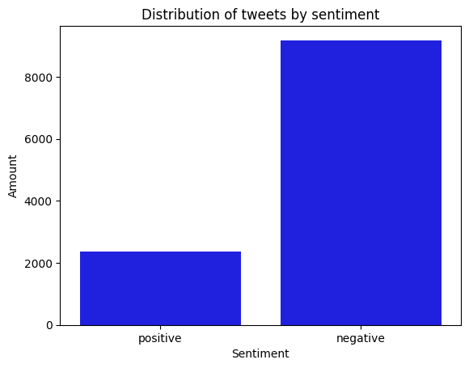

```
Example of a positive tweet:
@VirginAmerica plus you've added commercials to the experience... tacky.
Example of a negative tweet:
@VirginAmerica it's really aggressive to blast obnoxious "entertainment" in your guests' faces &amp; they have little recourse
```

```python
sns.countplot(data=df, x="airline_sentiment", color="blue")
plt.title("Distribution of tweets by sentiment")
plt.xlabel("Sentiment")
plt.ylabel("Amount")
plt.show()

print("Example of a positive tweet:")
print(df[df['airline_sentiment'] == 'positive']["text"].values[0])

print("Example of a negative tweet:")
print(df[df['airline_sentiment'] == 'negative']["text"].values[0])
```

There is class imbalance, as there are more negative tweets, and we should be cautious when training the model.

### 5.3 WorldCloud and LDA

It was identified which words and topics are most used in the tweets according to sentiment. Word cloud and LDA techniques were used to carry out this step.

```python
df_pos = df[df['airline_sentiment'] == 'positive']
df_neg = df[df['airline_sentiment'] == 'negative']
```

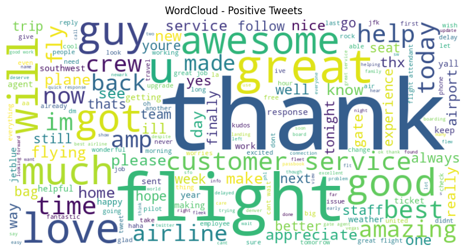

```python
wordcloud_pos = WordCloud(width=800, height=400, background_color='white').generate(" ".join(df_pos["clean_text"]))
plt.figure(figsize=(10, 5))
plt.imshow(wordcloud_pos, interpolation='bilinear')
plt.axis("off")
plt.title("WordCloud - Positive Tweets")
plt.show()
```

Top words used in positive tweets are thank, flight, great, awesome, 'customer, crew, love and service .

The word clouds reflect an immense appreciation of the service received, by the crew, and overall satisfaction with the flight experience.

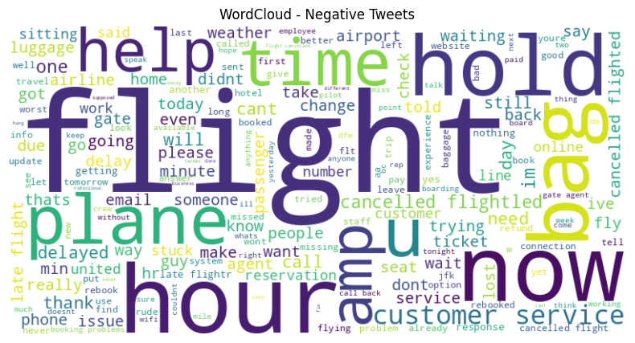

```python
wordcloud_neg = WordCloud(width=800, height=400, background_color='white').generate(" ".join(df_neg["clean_text"]))
plt.figure(figsize=(10, 5))
plt.imshow(wordcloud_neg, interpolation='bilinear')
plt.axis("off")
plt.title("WordCloud - Negative Tweets")
plt.show()
```

In negative tweets, the top words are: flight, hour, bag, hold, time, customer, cancelled, service, gate.

The word cloud shows that the main areas of discontent are with:Long waiting times, baggage problems or cancellations and customer service.

We select the text of the tweets by sentiment, then we obtain the topics for each sentiment using LDA, and at the end we visualize the results with a graph.

```python
nltk_stopwords = set(stopwords.words('english'))
texts_pos = [[word for word in text.split() if word not in nltk_stopwords] for text in df[df["airline_sentiment"] == "positive"]["clean_text"]]
texts_neg = [[word for word in text.split() if word not in nltk_stopwords] for text in df[df["airline_sentiment"] == "negative"]["clean_text"]]

def lda_topics(texts, sentiment_label):
    id2word = corpora.Dictionary(texts)
    corpus = [id2word.doc2bow(text) for text in texts]
    lda_model = gensim.models.LdaModel(corpus=corpus,
                                       id2word=id2word,
                                       num_topics=3,
                                       random_state=42,
                                       passes=10)
    topics = lda_model.show_topics(num_topics=3, num_words=5, formatted=False)
    topic_labels = []
    topic_weights = []

    for idx, topic in topics:
        words = ", ".join([w for w, _ in topic])
        topic_labels.append(f"{sentiment_label} - Topic {idx+1}: {words}")
        topic_weights.append(sum([weight for _, weight in lda_model.get_topic_terms(idx)]))

    return topic_labels, topic_weights

topic_labels_pos, topic_weights_pos = lda_topics(texts_pos, "Positive")
topic_labels_neg, topic_weights_neg = lda_topics(texts_neg, "Negative")
topic_labels_all = topic_labels_pos + topic_labels_neg
topic_weights_all = topic_weights_pos + topic_weights_neg
```

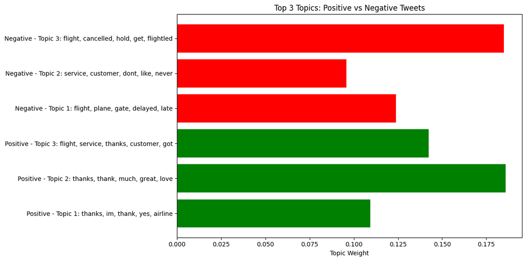

```python
plt.figure(figsize=(12, 6))
plt.barh(topic_labels_all, topic_weights_all, color=['green']*3 + ['red']*3)
plt.xlabel("Topic Weight")
plt.title("Top 3 Topics: Positive vs Negative Tweets")
plt.tight_layout()
plt.show()
```

In the positive tweets, themes indicated patterns on themes related to gratitude, service quality, friendliness of staff and general satisfaction with the flight. Keywords like "thank", "awesome", "crew", 'flight' and "customer" described the prevailing positive conversations. This indicates that users place a lot of importance on human attention and positive experiences while traveling.

Negative tweets were focused on specific service issues, such as delays, cancellations, lost luggage, or mismanagement of time. Recurring words were "hour", "bag", "cancelled", 'gate' and "service". This is a crucial finding which provides airlines with direct evidence on the key points that influence customer satisfaction.

## 6.Generate embeddings for each tweet

We transformed the texts into numerical vectors understandable to the model. For this, a pre-trained model "MiniLM" was used, which is optimized to generate text representations (embeddings) that reflect the meaning of the content.

This will facilitate the task of the classification model, as it makes it learn better between patterns of sentiment and expression of users on X (Twitter)

```python
model = SentenceTransformer('all-MiniLM-L6-v2')

embeddings = model.encode(df["clean_text"].tolist(), show_progress_bar=True)
```

```python
print("Embedding:", embeddings.shape)
```

```
Embedding: (11541, 384)
```

## 7.Model Training and Evaluation

We used logistic regression after obtaining the embeddings generated by MiniLM. Logistic regression was used because it is a fast and accurate algorithm for binary classification problems. For training we used 80% of the data and tested it with the remaining 20%.

```python
X_train, X_test, y_train, y_test = train_test_split(
    embeddings, df["airline_sentiment"], test_size=0.2, random_state=42
)

clf = LogisticRegression(max_iter=1000)
clf.fit(X_train, y_train)

y_pred = clf.predict(X_test)
```

```python
print(classification_report(y_test, y_pred))
```

```
              precision    recall  f1-score   support

    negative       0.94      0.97      0.95      1862
    positive       0.87      0.72      0.79       447

    accuracy                           0.93      2309
   macro avg       0.90      0.85      0.87      2309
weighted avg       0.92      0.93      0.92      2309
```

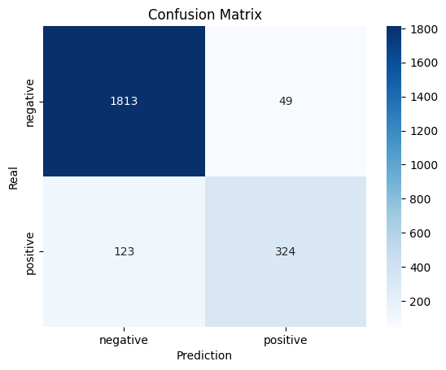

```python
conf_matrix = confusion_matrix(y_test, y_pred)
sns.heatmap(conf_matrix, annot=True, fmt='d', cmap='Blues',
            xticklabels=clf.classes_, yticklabels=clf.classes_)
plt.xlabel("Prediction")
plt.ylabel("Real")
plt.title("Confusion Matrix")
plt.show()
```

The confusion matrix reveals that the most common errors consist of classifying positives as negatives (false negatives), which can be improved in future work by applying balancing techniques or adjusting the decision threshold.

## 7.Example of prediction

We show an example of how to apply the learned model to predict the sentiment of an unseen tweet. In addition, we have an extraction module using the PageRank algorithm applied to sentences that allows to get in an unsupervised way the most representative sentences of the text.

We can use it in cases where content is long or where it is desired to provide a quick summary of the central message.

```python
def predict_sentiment(text):
    cleaned_text = clean_text(text)
    vector = model.encode([cleaned_text])
    prediction = clf.predict(vector)[0]
    return prediction

def summarize(text, top_n=1):
    sentences = text.split('.')
    sentences = [s.strip() for s in sentences if len(s.strip()) > 10]
    if len(sentences) <= 1:
        return text

    vectorizer = TfidfVectorizer()
    X = vectorizer.fit_transform(sentences)
    sim_matrix = cosine_similarity(X)

    graph = nx.from_numpy_array(sim_matrix)
    scores = nx.pagerank(graph)
    ranked = sorted(((scores[i], s) for i, s in enumerate(sentences)), reverse=True)
    summary = ' '.join([s for _, s in ranked[:top_n]])
    return summary

new_tweet = (
    "@United worst experience ever. Flight delayed 6 hours without explanation, rude staff at the gate, and my luggage was lost. Completely unacceptable."
)
print("Tweet:" , new_tweet )
print("Sentiment Prediction :", predict_sentiment(new_tweet))
print("Tweet Summary:", summarize(new_tweet))
print("--------------------------------------------------------")
new_tweet2 = (
    "@Delta I just had the most amazing flight! The crew was incredibly kind,everything was on time, and the in-flight service was top-notch. Absolutely loved it!"
)
print("Tweet:" , new_tweet2 )
print("Sentiment Prediction :", predict_sentiment(new_tweet2))
print("Tweet Summary:", summarize(new_tweet2))
```

```
Tweet: @United worst experience ever. Flight delayed 6 hours without explanation, rude staff at the gate, and my luggage was lost. Completely unacceptable.
Sentiment Prediction : negative
Tweet Summary: Flight delayed 6 hours without explanation, rude staff at the gate, and my luggage was lost
--------------------------------------------------------
Tweet: @Delta I just had the most amazing flight! The crew was incredibly kind,everything was on time, and the in-flight service was top-notch. Absolutely loved it!
Sentiment Prediction : positive
Tweet Summary: Absolutely loved it!
```

## 8.Conclusion

This project demonstrates the power of sentiment analysis of US airline tweets by applying NLP utilities such as MiniLM for semantic embeddings, supervised classification, topic modeling using LDA, and forecasting sentiments of future tweets through machine learning algorithms. This information can be used by airlines to amend their strategy and improve customer experience more accurately.

The model worked very well and is therefore very good at identifying the emotions expressed by social network users. In addition, other useful functions were added, such as the prediction of new tweets and the automatic summary of these.

Practically, from an interest point of view, this pipeline is helpful to airlines because it helps them:

- Track real-time mood of audiences.
- Determine the most important reasons for customer dissatisfaction or satisfaction.
- Focus on improving the service in the most important areas (e.g. customer service, delay, baggage).
- Obtain early warnings of reputational crisis

## 9.References

- Crowdflower. (2016). Twitter US Airline Sentiment. [online] Kaggle. Available at: https://www.kaggle.com/datasets/crowdflower/twitter-airline-sentiment [Accessed 27 Jun. 2025].